# Árboles de regresión: 1 regresor

# 1 Introducción

# 2 Arbol con un regresor cuantitativo

## 2.1 Construcción del árbol

```r
library(rpart)
d = read.csv('datos/kidiq.csv')
```

```r
# method = "anova" para modelos de regresion
t1 = rpart(kid_score ~ mom_iq, data = d, method = "anova")
```

```r
plot(t1, margin = 0.02)
text(t1, cex = 0.75)
```

[output not shown]

```r
print(t1)
```

```
## n= 434
##
## node), split, n, deviance, yval
##       * denotes terminal node
##
## 1) root 434 180386.20 86.79724
##   2) mom_iq< 84.33641 69  29011.83 66.86957 *
##   3) mom_iq>=84.33641 365 118793.70 90.56438
##     6) mom_iq< 101.8061 191  58829.52 85.31937 *
##     7) mom_iq>=101.8061 174  48941.98 96.32184 *
```

Lo que devuelve la tabla es:

- Numero del nodo
- split: criterio para hacer la partición del nodo
- n: numero de datos que componen el nodo.
- deviance: RSS = $\sum(y_i - \hat{y}_i)^2$
- yval: predicción del nodo = $\bar{y}$
- un asterisco * para indicar un nodo terminal u hoja.

Por ejemplo, para el nodo raiz:

- Predicción:

```r
(yp_root = mean(d$kid_score))
```

```
## [1] 86.79724
```

- Deviance:

```r
( deviance_root = sum( (d$kid_score - yp_root)^2 ) )
```

```
## [1] 180386.2
```

Para el nodo 3:

- Datos que pertenecen al nodo 3:

```r
d3 = d[d$mom_iq >= 84.33641,]
```

- Predicción:

```r
(yp_3 = mean(d3$kid_score))
```

```
## [1] 90.56438
```

- Deviance:

```r
( deviance_3 = sum( (d3$kid_score - yp_3)^2 ) )
```

```
## [1] 118793.7
```

## 2.2 Parámetros del árbol

```r
t2 = rpart(kid_score ~ mom_iq, data = d, method = "anova",
    control = rpart.control(minsplit = 10, minbucket = 5, cp = 0.05))
plot(t2, margin = 0.02)
text(t2, cex=.75)
```

[output not shown]

control:

- minsplit: número mínimo de observaciones del nodo para que se divida en dos (por defecto, minsplit = 20).
- minbucket: número mínimo de observaciones en un nodo terminal u hoja (por defecto, minbucket = minsplit/3).
- maxdepth: se fija el nivel máximo de cualquier nodo del árbol, siendo 0 el nivel del nodo raiz.
- cp: complexity parameter. En árboles de regresión, para que un nodo se divida, el R2 tiene que incrementarse en más de una cantidad data. En este caso: [RSS(padre) - RSS(hijo1) - RSS(hijo2)]/RSS(raiz) > cp (por defecto, cp = 0.01).
- xval: número de validaciones cruzadas. Se utiliza para el podado.

```r
print(t2)
```

```
## n= 434
##
## node), split, n, deviance, yval
##       * denotes terminal node
##
## 1) root 434 180386.20 86.79724
##   2) mom_iq< 84.33641 69  29011.83 66.86957 *
##   3) mom_iq>=84.33641 365 118793.70 90.56438
##     6) mom_iq< 101.8061 191  58829.52 85.31937 *
##     7) mom_iq>=101.8061 174  48941.98 96.32184 *
```

- Como vemos, en este caso el criterio que detiene el crecimiento del árbol es cp. Por ejemplo, el nodo 3 se ha dividido ya que

```r
(118793.70 - 58829.52 - 48941.98)/180386.20
```

```
## [1] 0.06110334
```

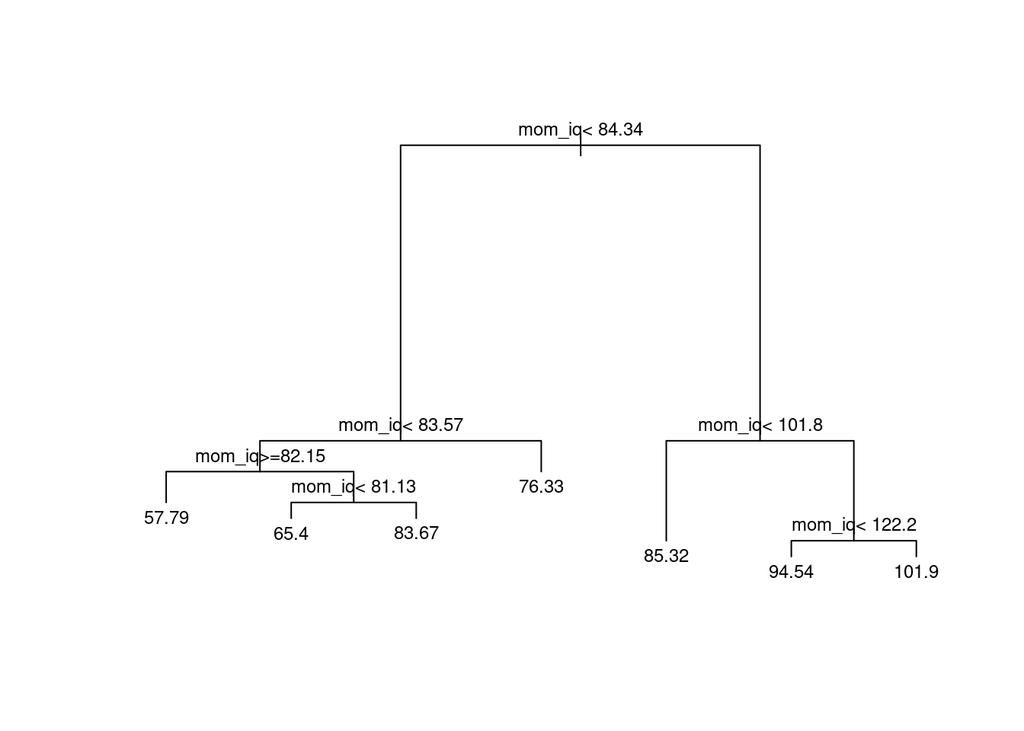

```r
t3 = rpart(kid_score ~ mom_iq, data = d, method = "anova",
    control = rpart.control(minsplit = 10, minbucket = 5, cp = 0.0069))
plot(t3, margin = 0.02)
text(t3, cex=.75)
```

```r
print(t3)
```

```
## n= 434
##
## node), split, n, deviance, yval
##       * denotes terminal node
##
##  1) root 434 180386.200  86.79724
##    2) mom_iq< 84.33641 69  29011.830  66.86957
##      4) mom_iq< 83.57478 60  26044.850  65.45000
##        8) mom_iq>=82.1513 14   5136.357  57.78571 *
##        9) mom_iq< 82.1513 46  19835.830  67.78261
##         18) mom_iq< 81.13004 40  14465.600  65.40000 *
##         19) mom_iq>=81.13004 6   3629.333  83.66667 *
##      5) mom_iq>=83.57478 9   2040.000  76.33333 *
##    3) mom_iq>=84.33641 365 118793.700  90.56438
##      6) mom_iq< 101.8061 191  58829.520  85.31937 *
##      7) mom_iq>=101.8061 174  48941.980  96.32184
##       14) mom_iq< 122.2355 132  38970.810  94.53788 *
##       15) mom_iq>=122.2355 42   8230.786 101.92860 *
```

- vemos que el nodo 7 en t2 no se dividía pero en t3 si se divide ya que:

```r
(48941.980 - 38970.810 - 8230.786)/180386.200
```

```
## [1] 0.009648099
```

- De nuevo cp es el parámetro más restrictivo.

## 2.3 Residuos

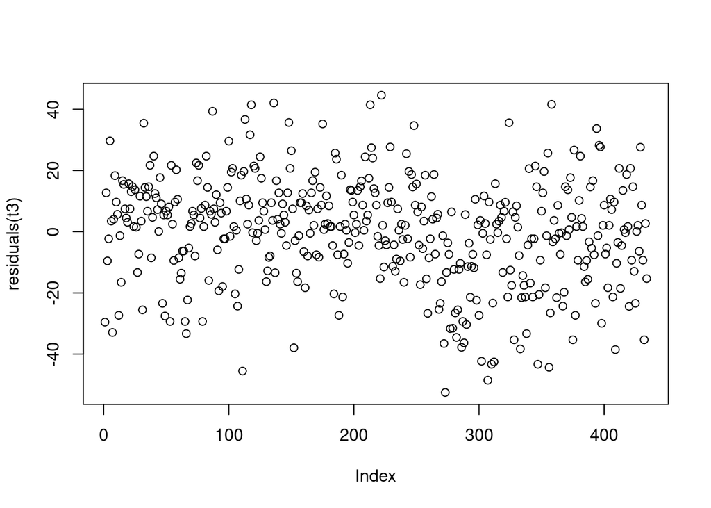

```r
plot(residuals(t3))
```

- El R2 se define a manera análoga a regresión

$$R^2 = 1 - \frac{RSS}{TSS}$$

- donde RSS = $\sum e_i^2 = \sum deviance(hoja_i)$ y TSS = deviance(root)
- Se denomina error relativo al cociente RSS/TSS. Y la X indica que se ha calculado mediante validación cruzada.

```r
par(mfrow = c(1,2))
rsq.rpart(t3)
```

```
##
## Regression tree:
## rpart(formula = kid_score ~ mom_iq, data = d, method = "anova",
##     control = rpart.control(minsplit = 10, minbucket = 5, cp = 0.0069))
##
## Variables actually used in tree construction:
## [1] mom_iq
##
## Root node error: 180386/434 = 415.64
##
## n= 434
##
##          CP nsplit rel error  xerror     xstd
## 1 0.1806158      0   1.00000 1.00274 0.065024
## 2 0.0611036      1   0.81938 0.84728 0.058712
## 3 0.0096481      2   0.75828 0.79453 0.056327
## 4 0.0069121      3   0.74863 0.86242 0.059701
## 5 0.0069000      6   0.72790 0.89153 0.062770
```

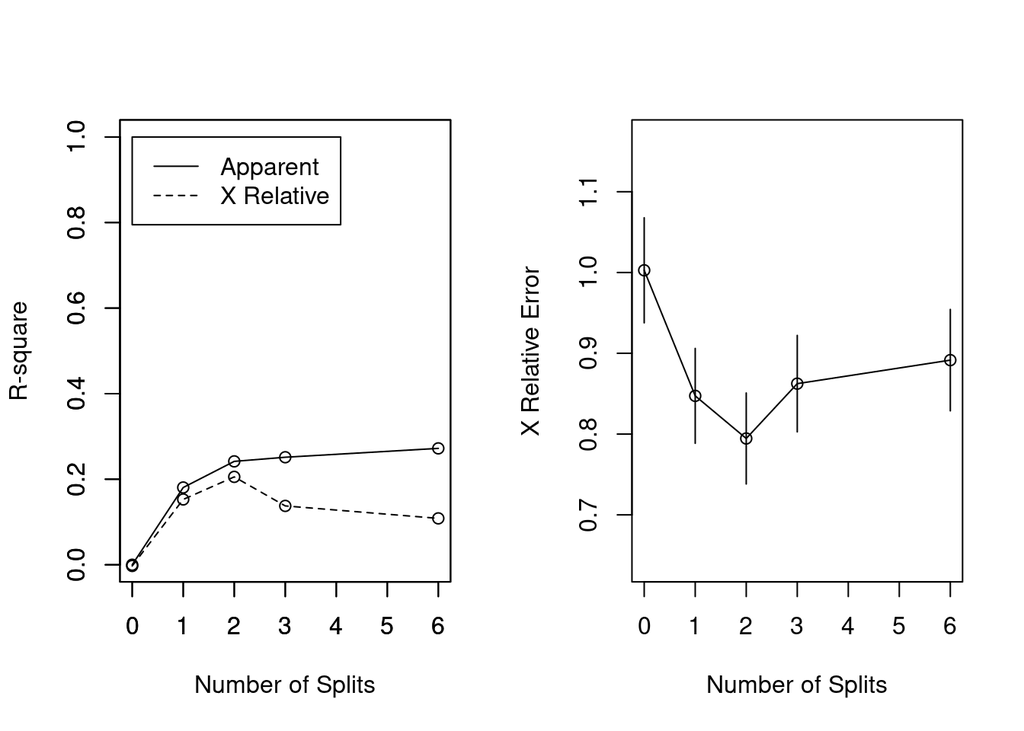

- Appatent: R2 calculado con la formula (1 - RSS/TSS)
- X Relative: R2 calculado con validación cruzada (como vemos, el R2 cuadrado con validación cruzada es menor que el apparent ya que uno esta calculado en los datos train y otro en los datos test).
- X relative error: 1 - X Relative, es decir, RSS/TSS. Está calculado con validación cruzada. Se dibuja el intervalo +/- SE calculado con validación cruzada.

# 3 Podado

- Los árboles que hemos visto se construyen de arriba hacia abajo, desde el nodo raiz hasta las hojas. Otra estrategia es construir un arbol muy profundo y luego podarlo. Construiriamos el arbol, por tanto, de abajo hacia arriba.
- Primero construimos un arbol profundo:

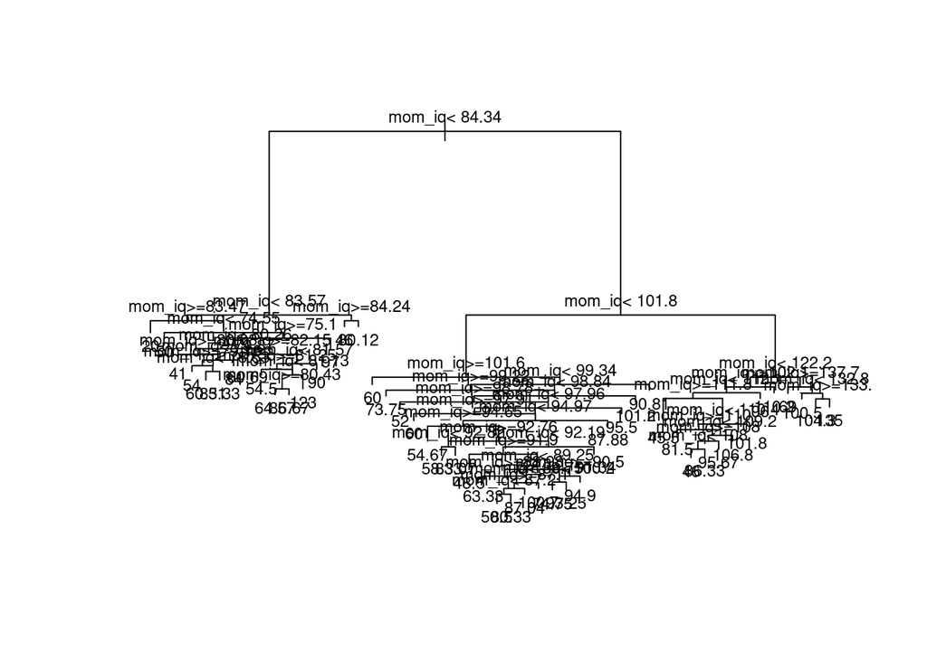

```r
t4 = rpart(kid_score ~ mom_iq, data = d, method = "anova",
    control = rpart.control(minsplit = 2, cp = 0.005))
plot(t4, margin = 0.02)
text(t4, cex=.75)
```

- Utilizando validación cruzada (el numero de validaciones viene dado por el parámetro xval), se determina el arbol con un determinado numero de hojas que tenga el mayor R2, o de manera equivalente, el menor error relativo.

```r
t4_printcp = printcp(t4) # lo guardamos en una variable para utilizarlo despues
```

```
##
## Regression tree:
## rpart(formula = kid_score ~ mom_iq, data = d, method = "anova",
##     control = rpart.control(minsplit = 2, cp = 0.005))
##
## Variables actually used in tree construction:
## [1] mom_iq
##
## Root node error: 180386/434 = 415.64
##
## n= 434
##
##           CP nsplit rel error  xerror     xstd
## 1  0.1806158      0   1.00000 1.00503 0.065431
## 2  0.0611036      1   0.81938 0.84436 0.058593
## 3  0.0106614      2   0.75828 0.78617 0.056071
## 4  0.0083922      6   0.71563 0.85314 0.061289
## 5  0.0074483      8   0.69885 0.92698 0.068632
## 6  0.0071830     10   0.68395 0.96620 0.073513
## 7  0.0062379     11   0.67677 0.99424 0.076778
## 8  0.0062370     16   0.64239 1.01822 0.077515
## 9  0.0057384     19   0.62368 1.02750 0.078904
## 10 0.0057042     20   0.61794 1.02597 0.079016
## 11 0.0056835     39   0.49145 1.01699 0.078452
## 12 0.0056244     40   0.48577 1.01665 0.078427
## 13 0.0055191     45   0.45765 1.03284 0.079389
## 14 0.0052498     46   0.45213 1.05642 0.080155
## 15 0.0050000     49   0.43638 1.08944 0.082479
```

- Salida de printcp():
  - col2: el valor de cp que hay que utilizar para obtener ese árbol
  - col3: numero de divisiones del arbol obtenido. Numero de hojas = numero divisiones + 1
  - col4: error relativo del arbol podado, RSS/TSS
  - col5: error relativo calculado con validación cruzada.
  - col6: desviación típica de xerror
- También se puede utilizar plotcp():

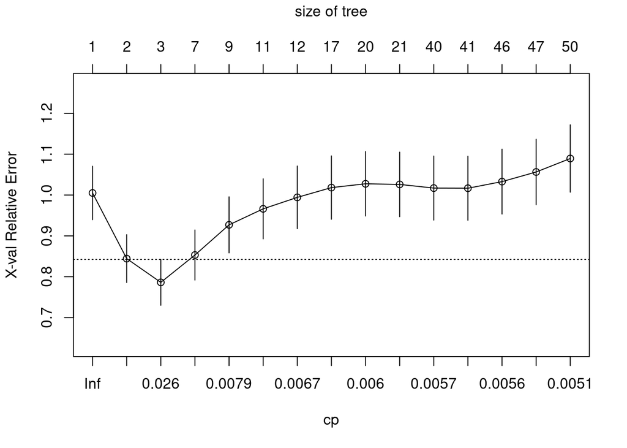

```r
plotcp(t4)
```

- A veces este gráfico tiene un mínimo, por lo que deberíamos seleccionar ese arbol. En caso contrario, elegimos el tamaño donde el error se estabilice.
- Según el gráfico y la tabla anterior, un arbol de 3 hojas (nsplit =2) parece razonable.

```r
(t4_cp = t4_printcp[3,"CP"])
```

```
## [1] 0.01066143
```

- Ahora podamos el arbol:

```r
t4_prune = prune(t4, cp = t4_cp)
plot(t4_prune, margin = 0.02)
text(t4_prune, cex=.75)
```

[output not shown]

En este caso se ha obtenido la misma solución que construyendo el árbol con los parámetros por defecto.

# 4 Prediccion

```r
xp = data.frame(mom_iq = 95)
predict(t4_prune, newdata = xp)
```

```
##        1
## 85.31937
```

- Mirando el arbol se puede verificar fácilmente la predicción.